# Coding Cookbook

Engineering Statistics I (MA223)

This document provides a list of the code most commonly used in the course. There may be times, especially when working on your capstone project(s), when you want to move beyond what we discuss in class. There are many resources available online, or feel free to ask for guidance from the instructor. However, the majority of code you will need for the course is documented here.

Throughout this document, we will be making use of the `mtcars` dataset available with all R installations. More information can be found about the variables in this dataset by typing `?mtcars` into your R console or typing `mtcars` into the help search box in RStudio. Here are the first few records of the dataset:

|  | mpg | cyl | disp | hp | drat | wt | qsec | vs | am | gear | carb |
| --- | --- | --- | --- | --- | --- | --- | --- | --- | --- | --- | --- |
| Mazda RX4 | 21.0 | 6 | 160 | 110 | 3.90 | 2.620 | 16.46 | 0 | 1 | 4 | 4 |
| Mazda RX4 Wag | 21.0 | 6 | 160 | 110 | 3.90 | 2.875 | 17.02 | 0 | 1 | 4 | 4 |
| Datsun 710 | 22.8 | 4 | 108 | 93 | 3.85 | 2.320 | 18.61 | 1 | 1 | 4 | 1 |
| Hornet 4 Drive | 21.4 | 6 | 258 | 110 | 3.08 | 3.215 | 19.44 | 1 | 0 | 3 | 1 |
| Hornet Sportabout | 18.7 | 8 | 360 | 175 | 3.15 | 3.440 | 17.02 | 0 | 0 | 3 | 2 |
| Valiant | 18.1 | 6 | 225 | 105 | 2.76 | 3.460 | 20.22 | 1 | 0 | 3 | 1 |

As you progress through the following examples, remember that R is *case sensitive*.

# Basics

Before proceeding to the specific aspects of the course; let’s first talk about a few basics about programming in R.

## Packages

Throughout the course we will be using a standard suite of packages (additional functions which provide additional analytical capabilities). In order to ensure that you have all required functionality for the course, be sure that each RMarkdown file you write has the following block at the top, which should not be altered:

```r
# Note to Students:
#  Do not alter this block of code.
source(paste("https://raw.githubusercontent.com/",
             "reyesem/MA223-Additional-Files/master/MA223Styles.R", sep=""))
```

## Anatomy of RMarkdown File

An RMarkdown file is comprised of two components: basic text and “code chunks” which perform the analysis. When the document is compiled (“knit”) the code is evaluated and the results added seemlessly into your document. This encourages a reproducible workflow (someone can recreate all your results should the data change).

Code blocks can be added using the “Insert” button at the top of the script window. Code blocks have the following form:

````
```{r}
Code goes here...
```
````

Notice that the code blocks always begin and end with the triple backticks (found on your keyboard in the upper-left-hand corner witht the tilde).

## Anatomy of R Code

Most code chunks all look the same. Below is a very simple code chunk. Objects are “assigned” to an object using an equal sign (or arrow `<-`). The code essentially says that the thing on the left will contain anything generated on the right.

```r
# Comments (not evaluated) begin with a hashtag.
ObjectName = code to generate results
```

> Just typing the name of an object prints that object out; that output, in turn, will appear in your final document.

If we want to do something to that object, we will make use of the “pipe operator” (`%>%`) which essentially says take the thing before and use it in the next function. For example, we might summarise an object as follows:

```r
ObjectTwo = ObjectOne %>%
  summarise()
```

This code says take the thing called “ObjectOne” and “pipe it into” (use within) the summarise function; whatever the result of this operation is will be called “ObjectTwo.”

# Data Manipulation

Data is rarely perfect when we first obtain it. Often times, we will need to make changes. There are a few tasks which are performed regularly; these can generally be accomplished with the following two functions:

- `mutate()`: manipulate variables or make transformations.
- `filter()`: subset the data based on some criteria.

## mutate(): creating or changing variables

As an example, while the US measures fuel efficiency in miles per gallon, other countries often report the gallons required for a single mile. This new variable `Gallons_per_Mile` can be created using `mutate()`:

```r
mtcars = mtcars %>%
  mutate(Gallons_per_Mile = 1/mpg)
```

Notice that we use the pipe operator (`%>%`) here; this essentially says take the dataset `mtcars` and feed it into the `mutate()` function. The `mutate()` function itself uses the notation `New_Variable_Name = transformation of stuff`. In this case, we create a new variable within the dataset `mtcars`. The result is stored within a dataset called `mtcars` (since that is on the left of the equal sign), essentially overwriting the original dataset.

The first few records of this dataset are shown below:

| mpg | cyl | disp | hp | drat | wt | qsec | vs | am | gear | carb | Gallons_per_Mile |
| --- | --- | --- | --- | --- | --- | --- | --- | --- | --- | --- | --- |
| 21.0 | 6 | 160 | 110 | 3.90 | 2.620 | 16.46 | 0 | 1 | 4 | 4 | 0.048 |
| 21.0 | 6 | 160 | 110 | 3.90 | 2.875 | 17.02 | 0 | 1 | 4 | 4 | 0.048 |
| 22.8 | 4 | 108 | 93 | 3.85 | 2.320 | 18.61 | 1 | 1 | 4 | 1 | 0.044 |
| 21.4 | 6 | 258 | 110 | 3.08 | 3.215 | 19.44 | 1 | 0 | 3 | 1 | 0.047 |
| 18.7 | 8 | 360 | 175 | 3.15 | 3.440 | 17.02 | 0 | 0 | 3 | 2 | 0.053 |
| 18.1 | 6 | 225 | 105 | 2.76 | 3.460 | 20.22 | 1 | 0 | 3 | 1 | 0.055 |

## filter(): subsetting a variable

If we only want to look at a subset of the data, we use the `filter()` function. For example, suppose we only want to consider vehicles which have automatic transmissions. Further, we would like to store those in a new dataset called `automatic.only`, we use the following code:

```r
automatic.only = mtcars %>%
  filter(am == 0)
```

When making comparisons, `==` is asking “are you equal?” We keep the records for which we would anser “yes” to this question. The original `mtcars` dataset is not altered; it remains unchanged. Instead, we have taken it, filtered it down, and then stored the results in `automatic.only` (the first few records of which are shown below).

| mpg | cyl | disp | hp | drat | wt | qsec | vs | am | gear | carb | Gallons_per_Mile |
| --- | --- | --- | --- | --- | --- | --- | --- | --- | --- | --- | --- |
| 21.4 | 6 | 258.0 | 110 | 3.08 | 3.215 | 19.44 | 1 | 0 | 3 | 1 | 0.047 |
| 18.7 | 8 | 360.0 | 175 | 3.15 | 3.440 | 17.02 | 0 | 0 | 3 | 2 | 0.053 |
| 18.1 | 6 | 225.0 | 105 | 2.76 | 3.460 | 20.22 | 1 | 0 | 3 | 1 | 0.055 |
| 14.3 | 8 | 360.0 | 245 | 3.21 | 3.570 | 15.84 | 0 | 0 | 3 | 4 | 0.070 |
| 24.4 | 4 | 146.7 | 62 | 3.69 | 3.190 | 20.00 | 1 | 0 | 4 | 2 | 0.041 |
| 22.8 | 4 | 140.8 | 95 | 3.92 | 3.150 | 22.90 | 1 | 0 | 4 | 2 | 0.044 |

## recode(): Changing the values of a variable

When we work with categorical variables, we often want the values (or group labels) to be something readable. In order to do this, we may need to recode the data. Consider the variable `am` (transmission type). It is currently a 0/1 variable, and it is not obvious that 1 represents manual transmission and 0 automatic transmission. We can make this clearer by mutating the dataset and recoding that variable.

```r
mtcars = mtcars %>%
  mutate(am = recode(am,
                     `0` = "automatic",
                     `1` = "manual"))
```

| mpg | cyl | disp | hp | drat | wt | qsec | vs | am | gear | carb | Gallons_per_Mile |
| --- | --- | --- | --- | --- | --- | --- | --- | --- | --- | --- | --- |
| 21.0 | 6 | 160 | 110 | 3.90 | 2.620 | 16.46 | 0 | manual | 4 | 4 | 0.048 |
| 21.0 | 6 | 160 | 110 | 3.90 | 2.875 | 17.02 | 0 | manual | 4 | 4 | 0.048 |
| 22.8 | 4 | 108 | 93 | 3.85 | 2.320 | 18.61 | 1 | manual | 4 | 1 | 0.044 |
| 21.4 | 6 | 258 | 110 | 3.08 | 3.215 | 19.44 | 1 | automatic | 3 | 1 | 0.047 |
| 18.7 | 8 | 360 | 175 | 3.15 | 3.440 | 17.02 | 0 | automatic | 3 | 2 | 0.053 |
| 18.1 | 6 | 225 | 105 | 2.76 | 3.460 | 20.22 | 1 | automatic | 3 | 1 | 0.055 |

If we now wanted to go further and change “automatic” to “Automatic Transmission”, we could recode again; this time, since the variable is already a phrase, we do not use backticks.

```r
mtcars = mtcars %>%
  mutate(am = recode(am,
                     "automatic" = "Automatic Transmission",
                     "manual" = "Manual Transmission"))
```

> If your dataset has groups coded as numbers (like above when 0 = automatic and 1 = manual), it is best to recode in order for graphics and models to work appropriately.

# Numerical Summaries

Numerical summaries (statistics) tell us about the distribution of our sample. These also estimate the corresponding parameters of interest in the population.

## summary(): Summary of all variables

A quick summary of all the variables in the dataset can be obtained using the `summary()` function. This is great for quantitative variables but is not always useful with categorical variables.

```r
mtcars %>%
  summary()
```

```
      mpg             cyl             disp             hp
 Min.   :10.40   Min.   :4.000   Min.   : 71.1   Min.   : 52.0
 1st Qu.:15.43   1st Qu.:4.000   1st Qu.:120.8   1st Qu.: 96.5
 Median :19.20   Median :6.000   Median :196.3   Median :123.0
 Mean   :20.09   Mean   :6.188   Mean   :230.7   Mean   :146.7
 3rd Qu.:22.80   3rd Qu.:8.000   3rd Qu.:326.0   3rd Qu.:180.0
 Max.   :33.90   Max.   :8.000   Max.   :472.0   Max.   :335.0
      drat             wt             qsec             vs
 Min.   :2.760   Min.   :1.513   Min.   :14.50   Min.   :0.0000
 1st Qu.:3.080   1st Qu.:2.581   1st Qu.:16.89   1st Qu.:0.0000
 Median :3.695   Median :3.325   Median :17.71   Median :0.0000
 Mean   :3.597   Mean   :3.217   Mean   :17.85   Mean   :0.4375
 3rd Qu.:3.920   3rd Qu.:3.610   3rd Qu.:18.90   3rd Qu.:1.0000
 Max.   :4.930   Max.   :5.424   Max.   :22.90   Max.   :1.0000
      am                 gear            carb       Gallons_per_Mile
 Length:32          Min.   :3.000   Min.   :1.000   Min.   :0.02950
 Class :character   1st Qu.:3.000   1st Qu.:2.000   1st Qu.:0.04386
 Mode  :character   Median :4.000   Median :2.000   Median :0.05208
                    Mean   :3.688   Mean   :2.812   Mean   :0.05423
                    3rd Qu.:4.000   3rd Qu.:4.000   3rd Qu.:0.06483
                    Max.   :5.000   Max.   :8.000   Max.   :0.09615
```

## summarise(): Summarizing a single variable.

The `summarise()` function allows us to compute individual summaries of variables. The following code computes the average mpg of vehicles in the sample as well as the percent of vehicles which have a manual transmission.

```r
mtcars %>%
  summarise(Mean_MPG = mean(mpg),
            Pct_manual = 100*mean(am=="Manual Transmission"))
```

```
  Mean_MPG Pct_manual
1 20.09062     40.625
```

Notice that in order to compute the percent which have a manual transmission, we are really saying add up the total number of cars which have a manual transmission (`am=="Manual Transmission"`) and then divide by the total number of cars in the dataset (`mean()`); finally, multiply by 100 to get a percentage. Like `mutate()`, we can call the result anything we want.

## group_by(): Summarizing in each group.

One nice feature about `summarise()` is that it works well when the data is grouped. The following code splits the vehicles into groups based on the number of cylinders (4, 6, 8) the car has, and then computes the same summaries as above for all cars with the same number of cylinders. That is, we get the average MPG and fraction of manual cars for vehicles with 4 cylinders, for vehicles with 6 cyinders, and for vehicles with 8 cylinders.

```r
mtcars %>%
  group_by(cyl) %>%
  summarise(Mean_MPG = mean(mpg),
            Pct_manual = 100*mean(am=="Manual Transmission"))
```

```
# A tibble: 3 x 3
    cyl Mean_MPG Pct_manual
  <dbl>    <dbl>      <dbl>
1     4 26.66364   72.72727
2     6 19.74286   42.85714
3     8 15.10000   14.28571
```

The `group_by()` function is the key here. It splits the dataset into groups where all the records have the same value of the variable named in the function (in this case, cylinder `cyl`).

## List of functions for numerical summaries

The following table contains a list of functions used to construct common summaries.

List of functions for numerical summaries

| Numerical Summary | Function |
| --- | --- |
| Mean/Average | `mean(x)` |
| Standard Deviation | `sd(x)` |
| Median | `median(x)` |
| Minimum | `min(x)` |
| Maximum | `max(x)` |
| 25-th Percentile | `quantile(x, 0.25)` |
| 75-th Percentile | `quantile(x, 0.75)` |
| Percent | `100*mean(x=="value")` |

# Graphics

A picture is worth 1000 words. A good graphical summary of the data should not only be a first step in an analysis, but it should also accompany any good analysis to help convey the message of the data. All graphics in this class will be produced with the `qplot()` function. There may be times, especially for your capstone projects, in which you want to move beyond what we discuss in the class. If you are interested, I would encourage you to look at the `ggplot2` package and would guide you toward the [Ggplot Cheat Sheet](https://www.rstudio.com/wp-content/uploads/2015/03/ggplot2-cheatsheet.pdf). However, all required graphics for this course can be constructed using `qplot()`.

The `qplot()` function has a couple of basic components:

- `data =` specifies the data set in which the variables exist.
- `x =` specifies the variable for the x-axis.
- `y =` if needed, specifies the variable for the y-axis.
- `geom =` determines the way the data is displayed on the graphic.

Additional components allow you to group similar observations based on another variable. The idea is to “map” variables to attributes of the graphic:

- `color =` specifies which variable in the data determines the exterior color of the objects.
- `fill =` specifies which variable in the data determines the fill-color of the objects plotted.
- `size =` specifies which variable in the data determines the size of the objects plotted.
- `shape =` specifies which variable in the data determines the shape of the objects plotted.

In addition to the components above, we can “add” labels using the `labs()` function. As the examples below illustrate, labels are defined by the features set in the graphic command itself (`x`, `y`, `color`, etc.). We now discuss various ways of combining these settings to create common graphics.

## Categorical Variable: Bar Chart

A bar chart is the simplest (and often best) method for summarizing the distribution of a categorical variable. The key steps to making a bar chart include:

1. Place the variable you want to summarize on the x-axis.
2. Set `geom = "bar"`.
3. Note: nothing goes on the y-axis.

For example, we can summarize the number of vehicles with each type of transmission using the following code.

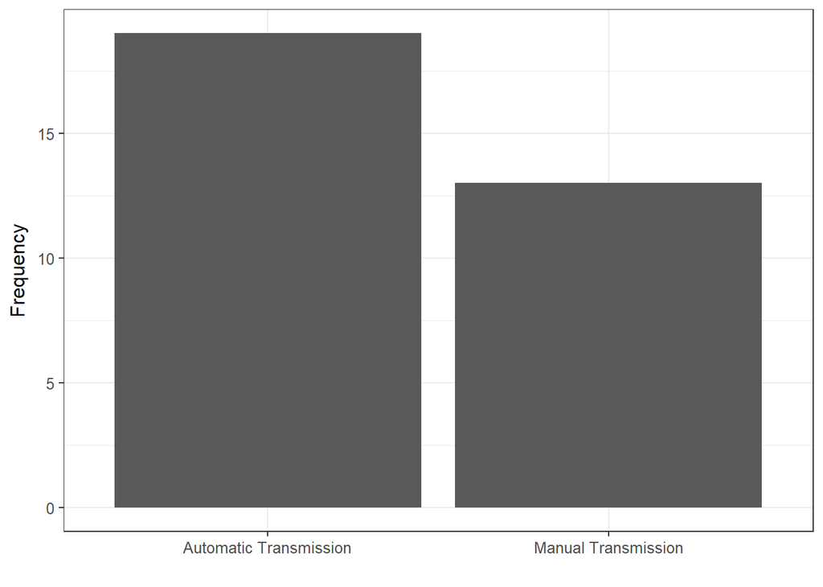

```r
qplot(data = mtcars,
      x = am,
      geom = "bar") +
  labs(x = "",
       y = "Frequency")
```

We remove the label on the x-axis because the value of the variable makes it clear what is being summarized.

## Multiple Categorical Variables: Bar Charts

If you have multiple categorical variables, consider using additional aesthetics to group variables. We will consider a bar chart summarizing the type of engine and the type of transmission for each vehicle. First, we clean up the way that the variable `vs` is coded:

```r
mtcars = mtcars %>%
  mutate(vs = recode(vs,
                     `0` = "V Engine",
                     `1` = "Straight Engine"))
```

Now, we construct the graphic using the following steps:

1. Place primary variable of interest on x-axis.
2. Use `fill =` to set the secondary variable.
3. Use `geom = "bar"`.

Again, we remove the labels of both the `fill` and the `x` variables because the values are self-evident.

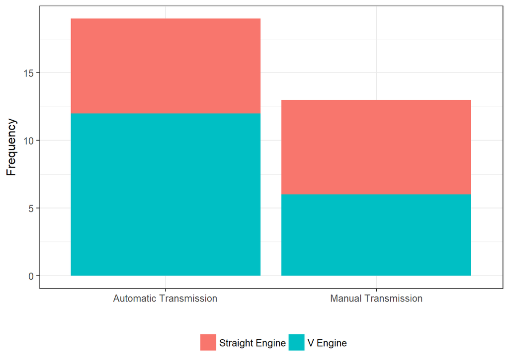

```r
qplot(data = mtcars,
      x = am,
      fill = vs,
      geom = "bar") +
  labs(x = "",
       fill = "",
       y = "Frequency")
```

## Quantitative Variable: Histogram

When looking at the distribution of a single variable, a histogram is a reasonable choice, especially for medium-sized datasets.

1. Set the variable to summarize on the x-axis.
2. Choose `geom = "histogram"`.
3. Set the `binwidth =` option to a reasonable size (how large do you want each bin to be). This changes for each problem and is a matter of opinion on what gives a reasonable looking graphic.

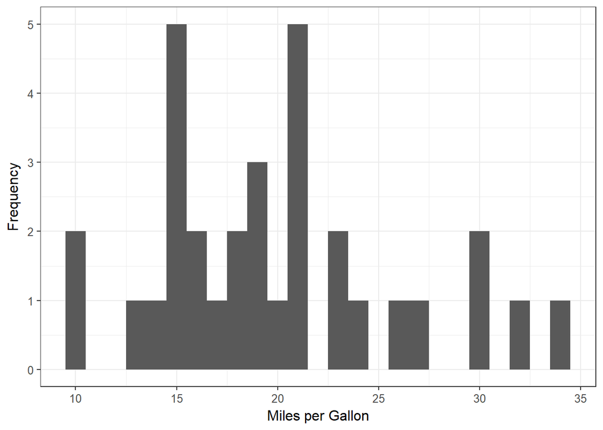

```r
qplot(data = mtcars,
      x = mpg,
      geom = "histogram",
      binwidth = 1) +
  labs(x = "Miles per Gallon",
       y = "Frequency")
```

In this graphic, we set the binwidth to be 1. We could also have considered a larger binwidth of 3, for example:

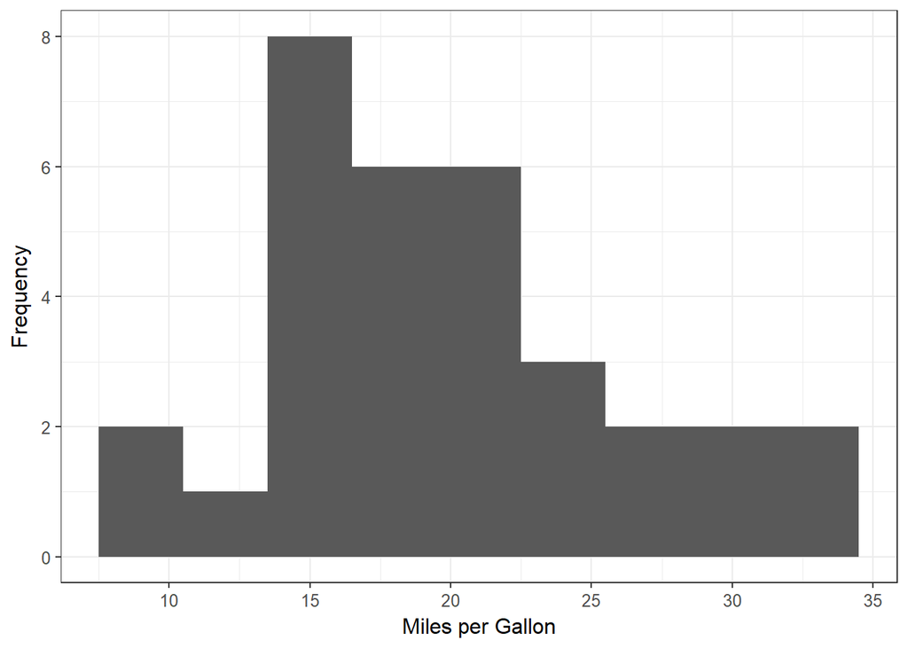

```r
qplot(data = mtcars,
      x = mpg,
      geom = "histogram",
      binwidth = 3) +
  labs(x = "Miles per Gallon",
       y = "Frequency")
```

If you exclude the `binwidth =` option, it will choose a value for you:

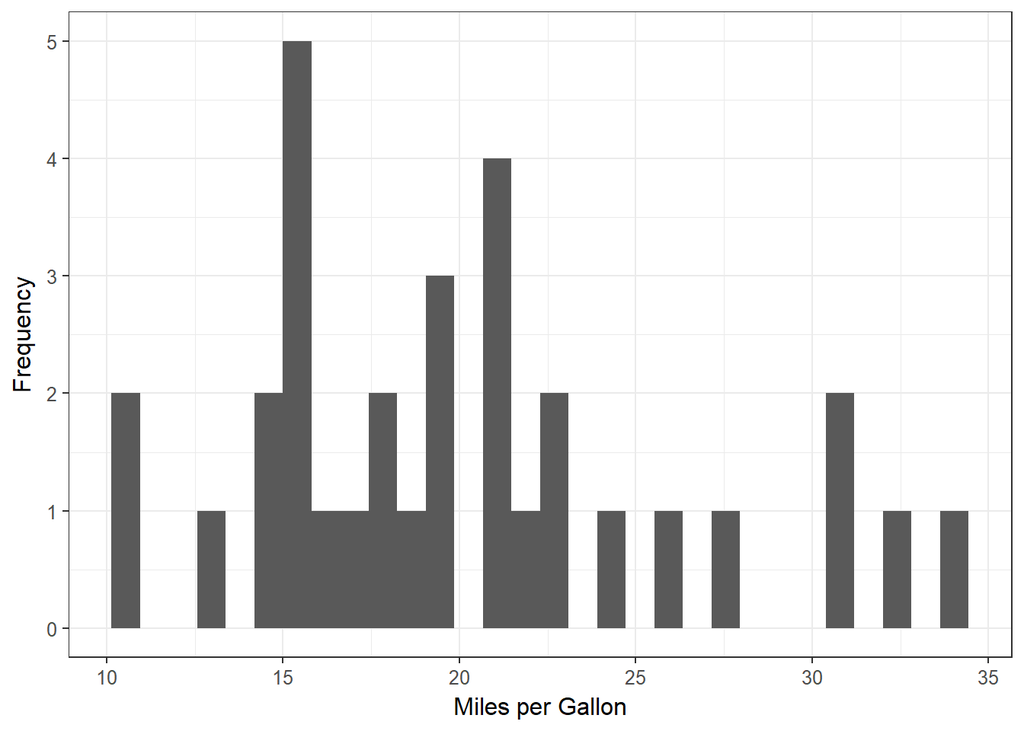

```r
qplot(data = mtcars,
      x = mpg,
      geom = "histogram") +
  labs(x = "Miles per Gallon",
       y = "Frequency")
```

## Quantitative Variable: Density

A density plot is like a smooth histogram; this works best with larger datasets.

1. Set the variable to summarize on the x-axis.
2. Choose `geom = "density"`

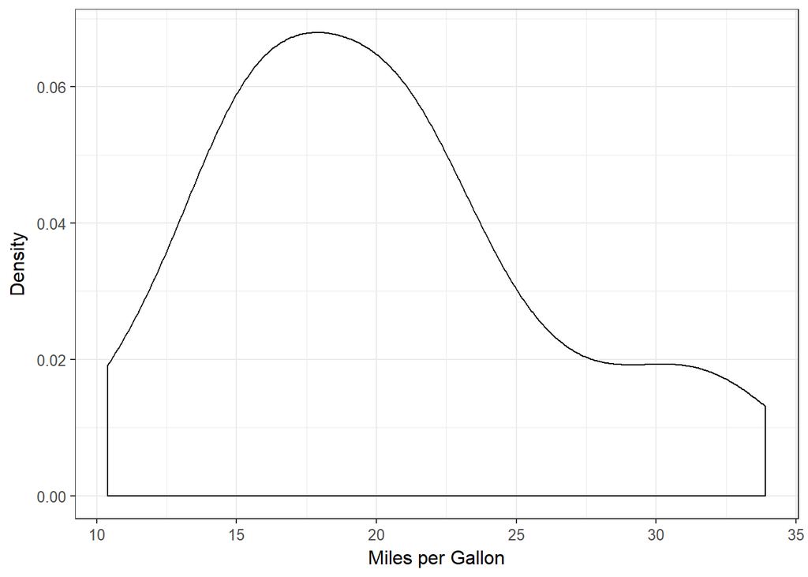

```r
qplot(data = mtcars,
      x = mpg,
      geom = "density") +
  labs(x = "Miles per Gallon",
       y = "Density")
```

The y-axis on this graphic is not directly interpretable; essentially they have been chosen such that the area under the curve is equal to 1. Our primary interest here is that larger values mean the values on the x-axis are more likely.

## Quantitative Variable Across Groups: Boxplots

If we are examining the distribution of a quantitative variable across various groups formed by a categorical variable, we can use side-by-side graphics, such as boxplots.

1. Set the variable to be summarized on the y-axis.
2. Place the grouping variable on the x-axis.
3. Set `geom = "boxplot"`.

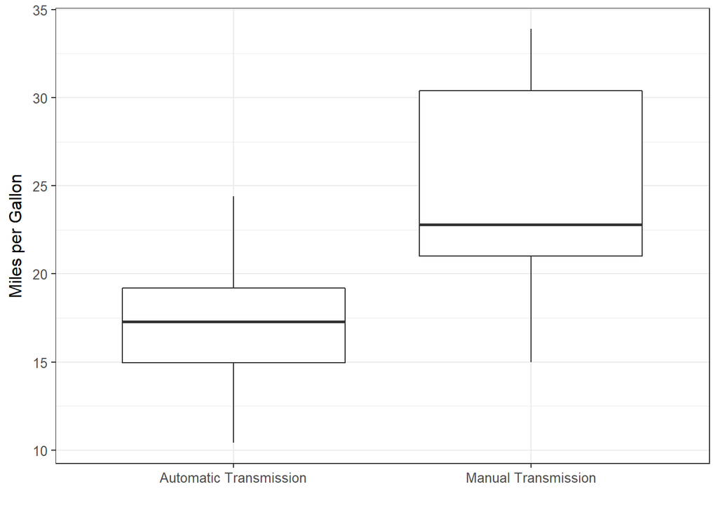

```r
qplot(data = mtcars,
      y = mpg,
      x = am,
      geom = "boxplot") +
  labs(x = "",
       y = "Miles per Gallon")
```

## Quantitative Variable Across Groups: Violin Plots

Boxplots summarize the center and spread of the data, but the shape is lost. Violin plots generalize boxplots by incorporating the shape.

1. Set the variable to be summarized on the y-axis.
2. Place the grouping variable on the x-axis.
3. Set `geom = "violin"`.

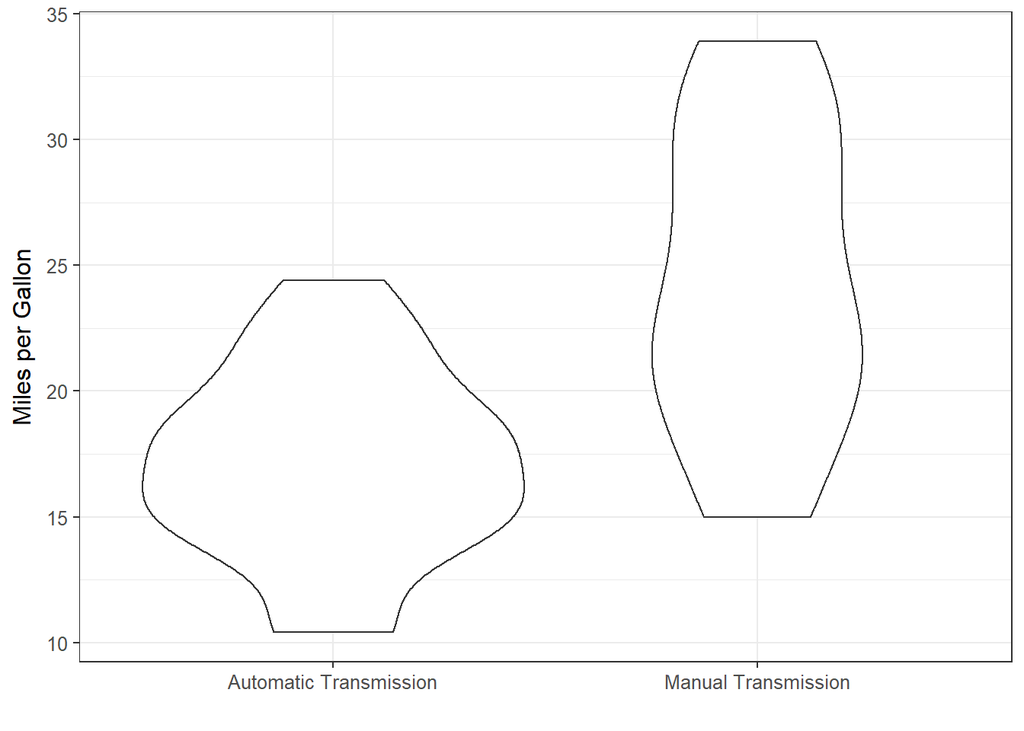

```r
qplot(data = mtcars,
      y = mpg,
      x = am,
      geom = "violin") +
  labs(x = "",
       y = "Miles per Gallon")
```

## Quantitative Variable Across Groups: Individual Value Plots

When we have a small sample, boxplots are inappropriate because they hide the raw data and present an overly confident summary. Instead, we prefer to place the raw values on the plot.

1. Set the variable to be summarized on the y-axis.
2. Place the grouping variable on the x-axis.
3. Set `geom = "point"`.

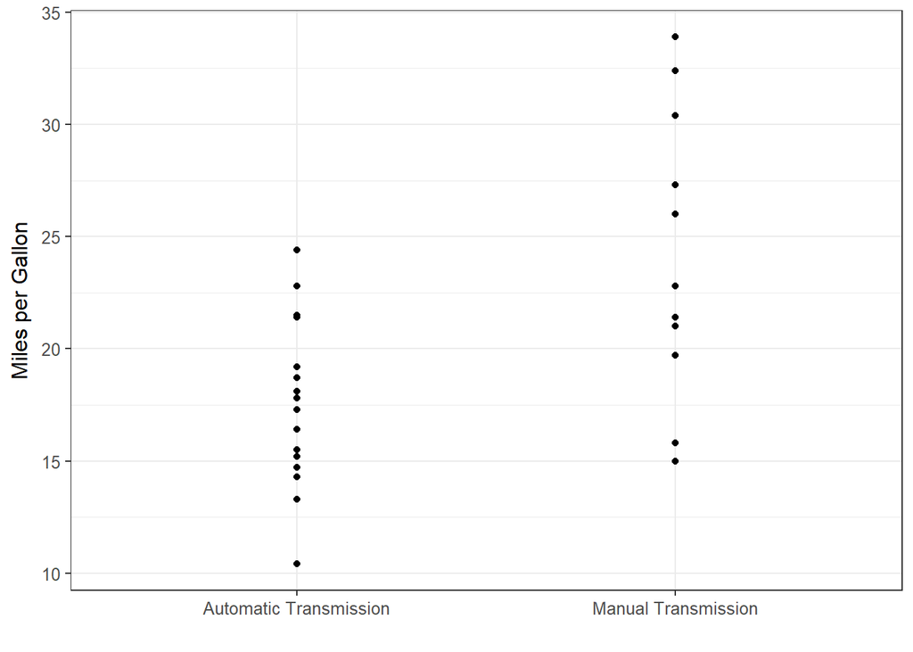

```r
qplot(data = mtcars,
      y = mpg,
      x = am,
      geom = "point") +
  labs(x = "",
       y = "Miles per Gallon")
```

If it looks too overwhelming because you have just enough points that they overlap, you can “jitter” the points:

1. Set the variable to be summarized on the y-axis.
2. Place the grouping variable on the x-axis.
3. Set `geom = "jitter"`.
4. Set `height = 0` to prevent the data from being jittered vertically.

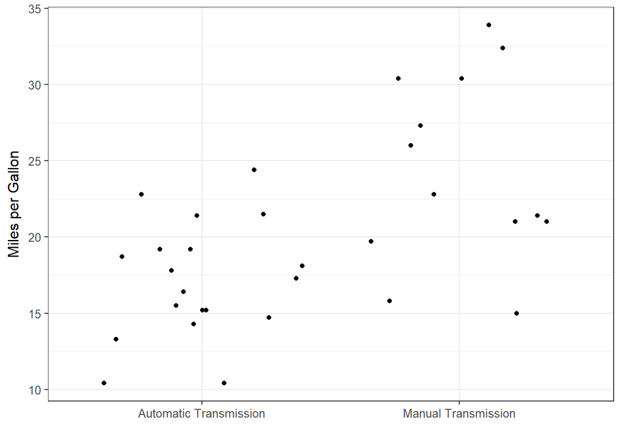

```r
qplot(data = mtcars,
      y = mpg,
      x = am,
      geom = "jitter",
      height = 0) +
  labs(x = "",
       y = "Miles per Gallon")
```

## Quantitative Variable Across Multiple Groups

Boxplots, Violin Plots, and Individual Value Plots can all be extended to include additional other groups by adding aesthetics. For example, we can construct a side-by-side boxplot which also fills according to the engine type.

1. Set variable to be summarized on the y-axis.
2. Set the primary grouping variable on the x-axis.
3. Set the secondary grouping variable as an aesthetic (`fill =`, `color =`, etc.)
4. Set `geom = "boxplot"` for example.

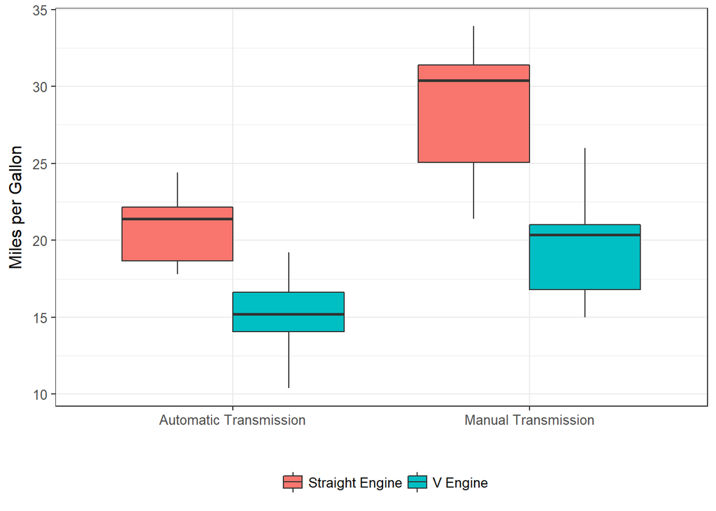

```r
qplot(data = mtcars,
      y = mpg,
      x = am,
      fill = vs,
      geom = "boxplot") +
  labs(x = "",
       y = "Miles per Gallon",
       fill = "")
```

## Two Quantitative Variables: Scatterplot

When examining the relationship between two quantitative variables, we can use a scatterplot.

1. Set the response (variable to be explained or predicted) on the y-axis.
2. Set the predictor (the “given” information) on the x-axis.
3. Set `geom = "point"`.

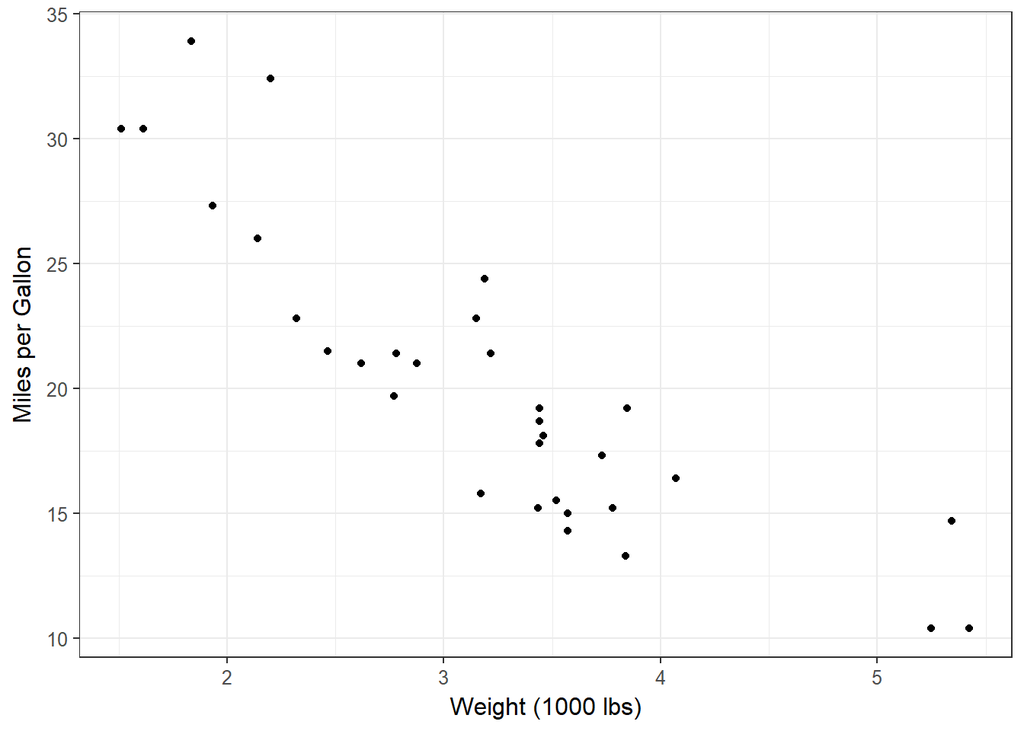

```r
qplot(data = mtcars,
      y = mpg,
      x = wt,
      geom = "point") +
  labs(y = "Miles per Gallon",
       x = "Weight (1000 lbs)")
```

## Adding Features to Scatterplots

Just as with other plots, we can add additional features to a scatterplot. In general, the following two guiding principles help when thinking about these additional aesthetics:

- Groups are best distinguished using color or shape.
- Quantitative variables are captured using color or size.

The following graphic examines the relationship between the fuel efficiency (MPG) of a vehicle and its weight, while also considering the transmission type of the vehicle. Since “transimission type” is categorical, we use the color to separate these groups.

1. Set the response (variable to be explained or predicted) on the y-axis.
2. Set the predictor (the “given” information) on the x-axis.
3. Set the grouping variable using `color =`.
4. Set `geom = "point"`.

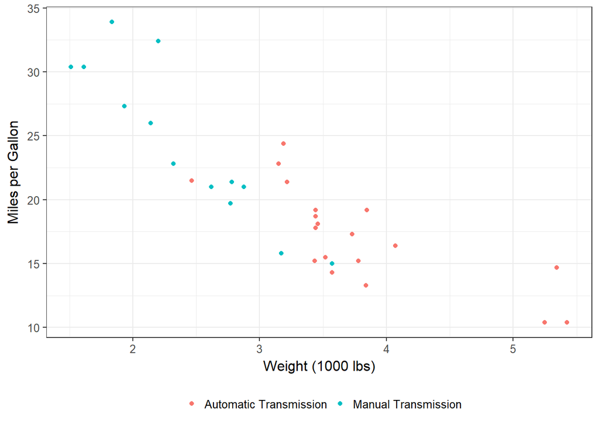

```r
qplot(data = mtcars,
      y = mpg,
      x = wt,
      color = am,
      geom = "point") +
  labs(y = "Miles per Gallon",
       x = "Weight (1000 lbs)",
       color = "")
```

We could also have used shape of the points instead.

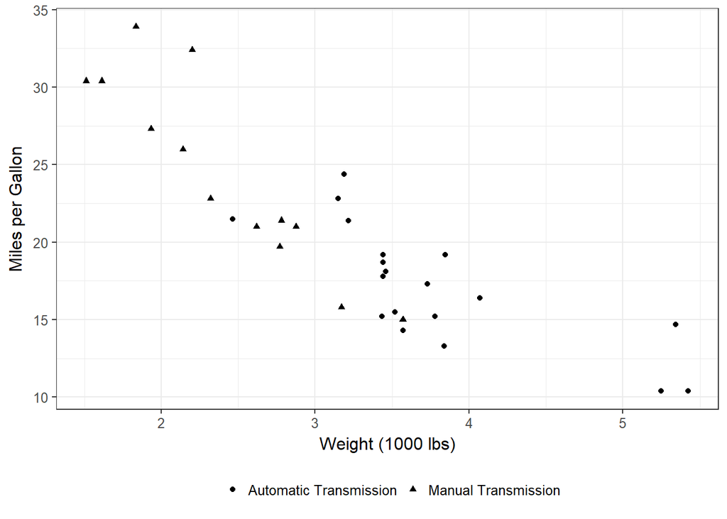

```r
qplot(data = mtcars,
      y = mpg,
      x = wt,
      shape = am,
      geom = "point") +
  labs(y = "Miles per Gallon",
       x = "Weight (1000 lbs)",
       shape = "")
```

If we want to look at the relationship between the fuel efficiency (MPG) of a vehicle and its weight, while also considering its horsepower, we do things a bit differently. Since “horsepower” is quantitative, we can use color or size to distinguish between various values. Both versions are shown below.

1. Set the response (variable to be explained or predicted) on the y-axis.
2. Set the predictor (the “given” information) on the x-axis.
3. Set the secondary predictor using `color =`.
4. Set `geom = "point"`.

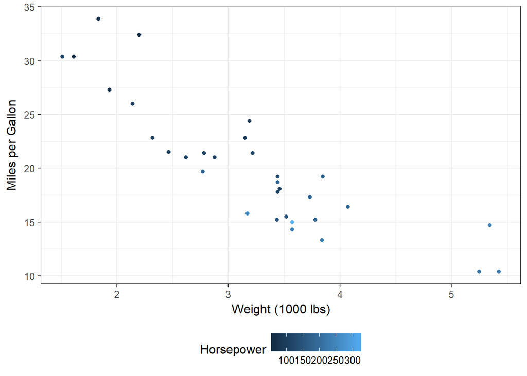

```r
qplot(data = mtcars,
      y = mpg,
      x = wt,
      color = hp,
      geom = "point") +
  labs(y = "Miles per Gallon",
       x = "Weight (1000 lbs)",
       color = "Horsepower")
```

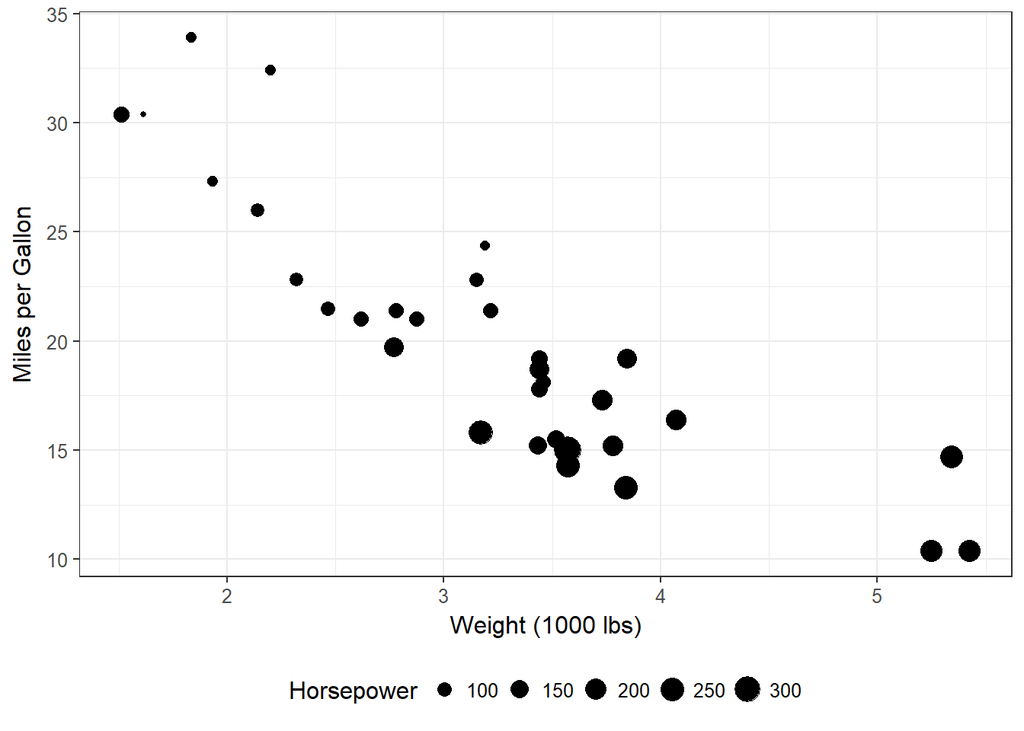

```r
qplot(data = mtcars,
      y = mpg,
      x = wt,
      size = hp,
      geom = "point") +
  labs(y = "Miles per Gallon",
       x = "Weight (1000 lbs)",
       size = "Horsepower")
```

## Adding a Smoother to a Scatterplot

If we would like to also include a smoother to show the overall trend of the plot, we must “layer” the various ways we present the data. Having “layers” just means using more than one `geom` at the same time.

1. Set the response (variable to be explained or predicted) on the y-axis.
2. Set the predictor (the “given” information) on the x-axis.
3. Set `geom = c("point", "smooth")` to place the smoother on top of the data.
4. Set `se = FALSE` to be sure that the plot is not too cluttered.

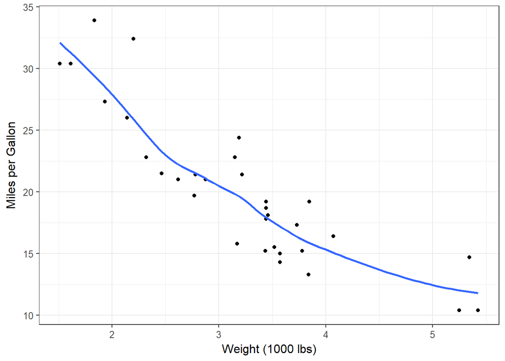

```r
qplot(data = mtcars,
      y = mpg,
      x = wt,
      geom = c("point", "smooth"),
      se = FALSE) +
  labs(y = "Miles per Gallon",
       x = "Weight (1000 lbs)")
```

## Adding a Best Fit Line to a Scatterplot

Instead of a smoother, we may want to place the “best fit” line on the graphic; the “best fit” line is actually just a special smoother. In order to do this, we add two additional options:

1. Set the response (variable to be explained or predicted) on the y-axis.
2. Set the predictor (the “given” information) on the x-axis.
3. Set `geom = c("point", "smooth")` to place the smoother on top of the data.
4. Set `se = FALSE` to be sure that the plot is not too cluttered.
5. Set `method = "lm"`.
6. Set `formula = y ~ x`

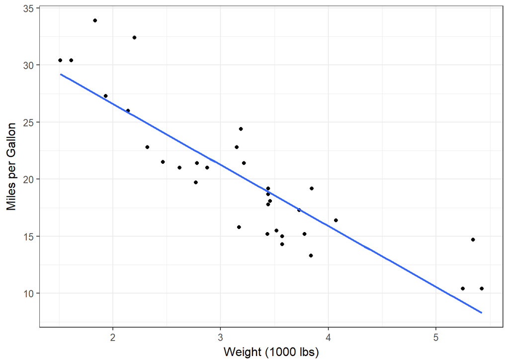

```r
qplot(data = mtcars,
      y = mpg,
      x = wt,
      geom = c("point", "smooth"),
      se = FALSE,
      method = "lm",
      formula = y ~ x) +
  labs(y = "Miles per Gallon",
       x = "Weight (1000 lbs)")
```

## Smoothing Lines Across Groups

Smoothers, just as any other type of graphic can be replicated across groups. For example, we can add the best fit line for both manual and automatic transmissions using the following steps:

1. Set the response (variable to be explained or predicted) on the y-axis.
2. Set the predictor (the “given” information) on the x-axis.
3. Set the grouping variable as the color.
4. Set `geom = c("point", "smooth")` to place the smoother on top of the data.
5. Set `se = FALSE` to be sure that the plot is not too cluttered.
6. Set `method = "lm"`.
7. Set `formula = y ~ x`

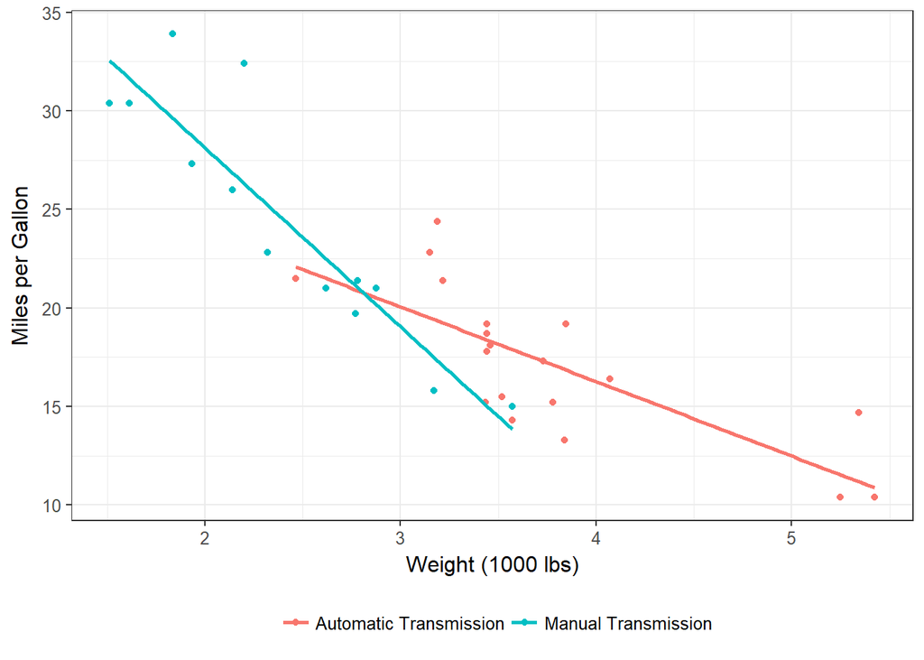

```r
qplot(data = mtcars,
      y = mpg,
      x = wt,
      color = am,
      geom = c("point", "smooth"),
      se = FALSE,
      method = "lm",
      formula = y ~ x) +
  labs(y = "Miles per Gallon",
       x = "Weight (1000 lbs)",
       color = "")
```

Hopefully, it is clear how we are taking base graphics (scatterplots), and adding a bit of information (smoothers) and then simply adding an additional aesthetic (color) and the rest takes care of itself. We add a bit of code to make an richer graphic.

# ANOVA Models

The first portion of the course is focused on the ANOVA model: comparing a quantitative response across the levels of a categorical variable. For our purposes, consider comparing the efficiency of vehicles with an automatic transmission to those with a manual transmission. Our model has the following form:

$$\begin{aligned}
(\text{MPG})_i &= \mu_1\mathbb{I}(\text{i-th vehicle has automatic transmission}) \\
&\quad + \mu_2\mathbb{I}(\text{i-th vehicle has manual transmission}) + \epsilon_i
\end{aligned}$$

## Fitting ANOVA Models

To fit the above model, we use the `lm()` function. The formula mirrors what is shown above: `response ~ group`. We ensure that we also specify the dataset. The `lm()` function computes an entire fit to the data (that is, it estimates the above parameters and computes the appropriate test statistic). This is a lot of information; so, we store it in some object (`fit.anova` in this case).

```r
fit.anova = lm(mpg ~ am, data = mtcars)
```

## Viewing the Classical ANOVA Table

In a classical ANOVA, the partitioning of the variability is summarized in an ANOVA table and the p-value comparing the average response across the groups is displayed in the ANOVA table. To view this table, we use `anova()` function. This is applied to the *model fit*, not the data.

```r
anova(fit.anova)
```

```
Analysis of Variance Table

Response: mpg
          Df Sum Sq Mean Sq F value   Pr(>F)
am         1 405.15  405.15   16.86 0.000285 ***
Residuals 30 720.90   24.03
---
Signif. codes:  0 '***' 0.001 '**' 0.01 '*' 0.05 '.' 0.1 ' ' 1
```

## Bootstrap P-Value

To compute the p-value under bootstrapping, we use the `boot_model()` function. However, the p-value requires the data be generated under the null hypothesis. Consider our hypothesis of interest:

$$H_0: \mu_1 = \mu_2 \qquad \text{vs.} \qquad H_1: \mu_1 \neq \mu_2$$

If the null hypothesis is true, the model for our data generating process would change to

$$(\text{MPG})_i = \mu + \epsilon_i$$

where $\mu$ is the overall mean response — the common value of $\mu_1$ and $\mu_2$. In order to construct the p-value we must communicate the null model to the program. We fit that as follows:

```r
fit.anova.h0 = lm(mpg ~ 1, data = mtcars)
```

where the 1 in the formula indicates we have only a single group. Now, to compute the p-value using `boot_model()` we do the following:

1. First give the full model, fit if alternative is true.
2. Second, pass the null model, fit if the null is true.
3. Set `constant.var = TRUE` to assume constant variance when bootstrapping or `constant.var = FALSE` to not assume constant variance.

```r
boot_model(fit.anova, fit.anova.h0, constant.var = TRUE)
```

```
Test Statistic: 16.86028
P-Value: 0.001
```

The output consists of two pieces: the test statistic and p-value for comparing the response across the levels of the categorical variable.

## Computing Residuals

Diagnostic graphics used to assess conditions on the stochastic portion of the model depend on residuals. In order to obtain the residuals, we “augment” the model fit. These results must be stored in a dataset.

1. First element is the model fit (from the full model under alternative).
2. As typical, we must specify the dataset we want to work with.

```r
mtcars.augment = augment(fit.anova, data = mtcars)
```

The result is actually a new dataset which includes various new variables (beginning with period in the name) used to assess a model fit. We will only focus on `.resid` which contains the residuals. The first few records of this new dataset are shown below:

| mpg | cyl | disp | hp | drat | wt | qsec | vs | am | gear | carb | Gallons_per_Mile | .fitted | .se.fit | .resid | .hat | .sigma | .cooksd | .std.resid |
| --- | --- | --- | --- | --- | --- | --- | --- | --- | --- | --- | --- | --- | --- | --- | --- | --- | --- | --- |
| 21.0 | 6 | 160 | 110 | 3.90 | 2.620 | 16.46 | V Engine | Manual Transmission | 4 | 4 | 0.048 | 24.392 | 1.360 | -3.392 | 0.077 | 4.943 | 0.022 | -0.720 |
| 21.0 | 6 | 160 | 110 | 3.90 | 2.875 | 17.02 | V Engine | Manual Transmission | 4 | 4 | 0.048 | 24.392 | 1.360 | -3.392 | 0.077 | 4.943 | 0.022 | -0.720 |
| 22.8 | 4 | 108 | 93 | 3.85 | 2.320 | 18.61 | Straight Engine | Manual Transmission | 4 | 1 | 0.044 | 24.392 | 1.360 | -1.592 | 0.077 | 4.976 | 0.005 | -0.338 |
| 21.4 | 6 | 258 | 110 | 3.08 | 3.215 | 19.44 | Straight Engine | Automatic Transmission | 3 | 1 | 0.047 | 17.147 | 1.125 | 4.253 | 0.053 | 4.919 | 0.022 | 0.891 |
| 18.7 | 8 | 360 | 175 | 3.15 | 3.440 | 17.02 | V Engine | Automatic Transmission | 3 | 2 | 0.053 | 17.147 | 1.125 | 1.553 | 0.053 | 4.977 | 0.003 | 0.325 |
| 18.1 | 6 | 225 | 105 | 2.76 | 3.460 | 20.22 | Straight Engine | Automatic Transmission | 3 | 1 | 0.055 | 17.147 | 1.125 | 0.953 | 0.053 | 4.983 | 0.001 | 0.200 |

## Diagnostic Plots: Time-Series Plot

If the data is recorded in the order in which it was collected, we can construct a time-series plot of the residuals.

1. Use the augmented dataset (see above) that contains the residuals.
2. Set `y = .resid`.
3. Set `x = seq_along(.resid)` to construct the order of the observations.
4. Set `geom = c("line", "point")` to connect the dots for an better view.

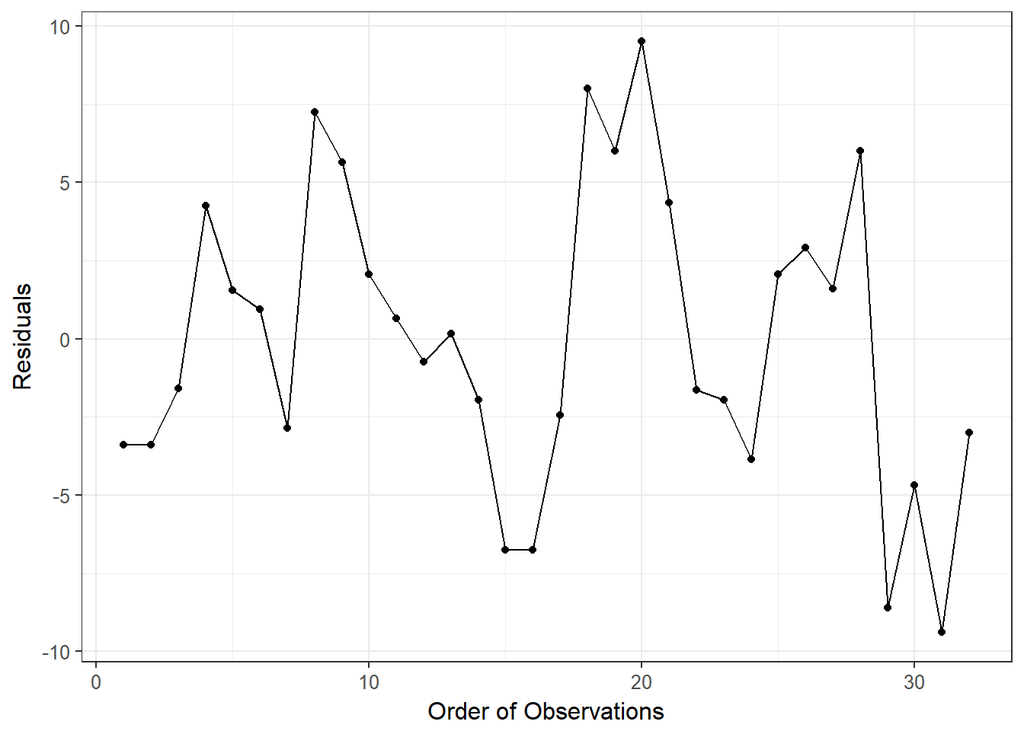

```r
qplot(data = mtcars.augment,
      y = .resid,
      x = seq_along(.resid),
      geom = c("line", "point")) +
  labs(y = "Residuals",
       x = "Order of Observations")
```

The nice thing about this graphic is that the only thing that changes is the dataset from which to pull the residuals.

## Diagnostic Plots: Boxplot of Residuals

Just as we examine boxplots of the response, we can examine residuals across the groups as well.

1. Use the augmented dataset (see above) that contains the residuals.
2. Set `y = .resid`.
3. Set `x =` the grouping variable used in the model.
4. Set `geom = "boxplot"` (or point if you want an individual value plot).

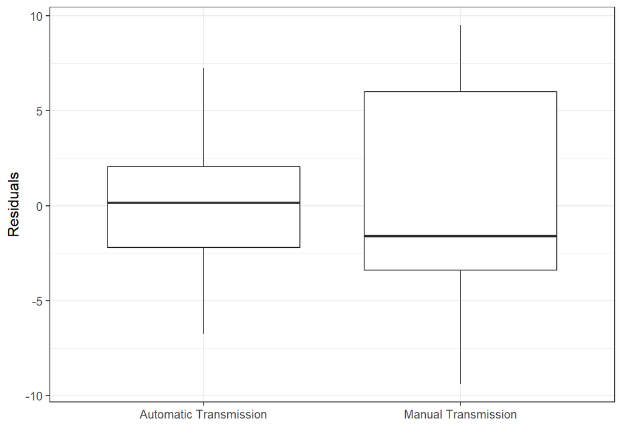

```r
qplot(data = mtcars.augment,
      y = .resid,
      x = am,
      geom = "boxplot") +
  labs(y = "Residuals",
       x = "")
```

## Diagnostic Plots: Probability Plot

A probability plot, or quanitile-quantile plot (QQ-plot for short) can also be made of the residuals.

1. Use the augmented dataset (see above) that contains the residuals.
2. Set `sample = .resid`.
3. Set `geom = "qq"`.

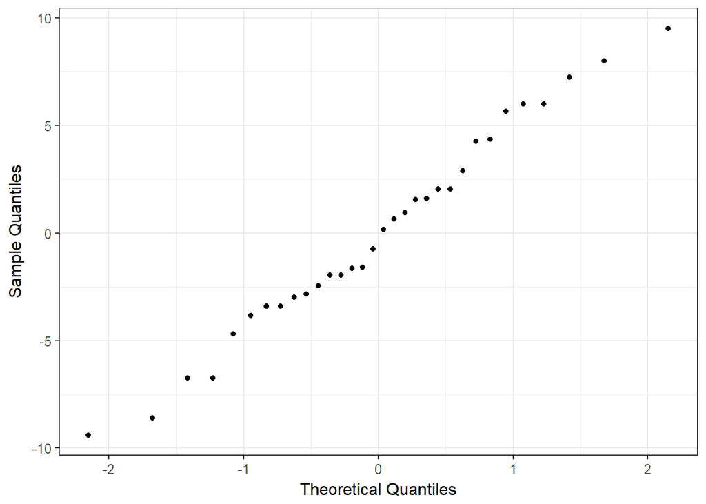

```r
qplot(data = mtcars.augment,
      sample = .resid,
      geom = "qq") +
  labs(x = "Theoretical Quantiles",
       y = "Sample Quantiles")
```

# Regression Models

Regression models are an extension of ANOVA models to include quantitative predictors. However, the majority of the code looks simple. For our purposes, consider the following model, which predicts the fuel efficiency as a function of the horse power of the car and the weight of the car.

$$(\text{MPG})_i = \beta_0 + \beta_1(\text{Weight})_i + \beta_2(\text{Horsepower})_i + \epsilon_i$$

## Fitting Regression Models: Least Squares Estimates

The “best fit” line typically encountered is formed by computing the least squares estimates of the parameters in the regression model. This is done using the `lm()` function.

> Additional predictors are separated by a `+` sign.

```r
fit.regression = lm(mpg ~ wt + hp, data = mtcars)
```

Here, `fit.regression` is an object which stores lots of information about the estimation procedure. To see the least squares estimates, as well as other characteristics about these estimates, we use the `tidy()` function.

```r
tidy(fit.regression)
```

```
         term    estimate  std.error statistic      p.value
1 (Intercept) 37.22727012 1.59878754 23.284689 2.565459e-20
2          wt -3.87783074 0.63273349 -6.128695 1.119647e-06
3          hp -0.03177295 0.00902971 -3.518712 1.451229e-03
```

## Obtaining p-values and Confidence Intervals for Classical Regression Model

If the conditions for the classical regression model hold, we can obtain p-values testing whether each parameter is 0, as well as confidence intervals for each parameter using `tidy()`.

```r
tidy(fit.regression, conf.int = TRUE, conf.level = 0.95)
```

```
         term    estimate  std.error statistic      p.value    conf.low
1 (Intercept) 37.22727012 1.59878754 23.284689 2.565459e-20 33.95738245
2          wt -3.87783074 0.63273349 -6.128695 1.119647e-06 -5.17191604
3          hp -0.03177295 0.00902971 -3.518712 1.451229e-03 -0.05024078
    conf.high
1 40.49715778
2 -2.58374544
3 -0.01330512
```

While p-values are always included, confidence intervals need to be requested (`conf.int = TRUE`). In order to change the confidence level, we set `conf.level` option.

## Bootstrapping Confidence Intervals

We use the `boot_model()` function to construct confidence intervals via bootstrapping. In order to bootstrap, we only need to know the model we are considering.

1. First element is the full model fit.
2. Use `constant.var = TRUE` to bootstrap assuming constant variance and `constant.var = FALSE` to bootstrap without assuming constant variance.
3. Use `conf.level` option to set the confidence level (default is 0.95 for 95% confidence intervals).

```r
boot_model(fit.regression, constant.var = FALSE, conf.level = 0.95)
```

```
95% CI:
# A tibble: 3 x 3
         term         LCL         UCL
        <chr>       <dbl>       <dbl>
1 (Intercept) 33.41117043 40.99662107
2          hp -0.04319382 -0.01799853
3          wt -4.98888621 -2.59633376
```

The output is a confidence interval for each parameter in the model.

## Bootstrapping p-values

We can also use `boot_model()` to compute a p-value via bootstrapping in a regression model. Just as we did for ANOVA, the key is that the bootstrapping must happen *assuming the null hypothesis*. That means we must specify a null hypothesis by specifying what the model looks like under the null hypothesis.

For example, for the model stated above, suppose we are considering the following hypotheses:

$$H_0: \beta_1 = 0 \qquad \text{vs.} \qquad H_1: \beta_1 \neq 0$$

Then, if the null hypothesis is true, our model for the data generating hypothesis becomes

$$(\text{MPG})_i = \beta_0 + \beta_2(\text{Horsepower})_i + \epsilon_i$$

suggesting that weight does not play a role in determining the fuel efficiency after accounting for the horsepower of the vehicle. We must communicate this model to the program.

```r
fit.regression.h0 = lm(mpg ~ hp, data = mtcars)
```

Now, we can bootstrap to construct the p-value.

1. First element is the full model (fit assuming alternative hypothesis).
2. Second element is the reduced model (fit assuming the null hypothesis).
3. Use `constant.var = TRUE` to bootstrap assuming constant variance and `constant.var = FALSE` to bootstrap without this assumption.

```r
boot_model(fit.regression, fit.regression.h0, constant.var = FALSE)
```

```
Test Statistic: 37.56091
P-Value: 0
```

## Computing R-Squared

R-squared is one measure for quantifying the predictive ability of the model. It can be obtained using the `glance()` function.

```r
glance(fit.regression)
```

```
  r.squared adj.r.squared    sigma statistic      p.value df    logLik
1 0.8267855     0.8148396 2.593412  69.21121 9.109054e-12  3 -74.32617
       AIC      BIC deviance df.residual
1 156.6523 162.5153 195.0478          29
```

We will only use the regular R-squared measure first listed there.

## Including Interactions in the Model

Consider the following model for the fuel efficiency, which extends our above model by including an interaction term.

$$(\text{MPG})_i = \beta_0 + \beta_1(\text{Weight})_i + \beta_2(\text{Horsepower})_i + \beta_3(\text{Weight})_i(\text{Horsepower})_i + \epsilon_i$$

A colon (`:`) is used to add an interaction term to a model.

```r
fit.interactions = lm(mpg ~ wt + hp + wt:hp, data = mtcars)
```

## Comparing Models via Classical Regression

We have seen that the `boot_model()` function compares two specified models using bootstrapping. What if we want to compare two models using classical regression? For example, suppose we want to test whether the interaction term from the previous section belongs in the model. This hypothesis is

$$H_0: \beta_3 = 0 \qquad \text{vs.} \qquad H_1: \beta_3 \neq 0$$

Notice that our `fit.regression` object is the fit of this model when there is no interaction term (when the null hypothesis is true), and `fit.interactions` is the fit of the model when there is an interaction (alternative hypothesis is true). We can use the `anova()` function to compare these.

1. First element is the reduced model (fit assuming null hypothesis).
2. Second element is the full model (fit assuming the alternative hypothesis).

Notice that this is the *reverse* of the `boot_model()` function.

```r
anova(fit.regression, fit.interactions)
```

```
Analysis of Variance Table

Model 1: mpg ~ wt + hp
Model 2: mpg ~ wt + hp + wt:hp
  Res.Df    RSS Df Sum of Sq      F    Pr(>F)
1     29 195.05
2     28 129.76  1    65.286 14.088 0.0008108 ***
---
Signif. codes:  0 '***' 0.001 '**' 0.01 '*' 0.05 '.' 0.1 ' ' 1
```

## Computing Residuals

Diagnostic graphics used to assess conditions on the stochastic portion of the model depend on residuals. In order to obtain the residuals, we “augment” the model fit. These results must be stored in a dataset.

1. First element is the model fit (from the full model under alternative).
2. As typical, we must specify the dataset we want to work with.

```r
mtcars.augment = augment(fit.regression, data = mtcars)
```

The result is actually a new dataset which includes various new variables (beginning with period in the name) used to assess a model fit. We will only focus on `.resid` which contains the residuals. The first few records of this new dataset are shown below:

| mpg | cyl | disp | hp | drat | wt | qsec | vs | am | gear | carb | Gallons_per_Mile | .fitted | .se.fit | .resid | .hat | .sigma | .cooksd | .std.resid |
| --- | --- | --- | --- | --- | --- | --- | --- | --- | --- | --- | --- | --- | --- | --- | --- | --- | --- | --- |
| 21.0 | 6 | 160 | 110 | 3.90 | 2.620 | 16.46 | V Engine | Manual Transmission | 4 | 4 | 0.048 | 23.572 | 0.546 | -2.572 | 0.044 | 2.592 | 0.016 | -1.015 |
| 21.0 | 6 | 160 | 110 | 3.90 | 2.875 | 17.02 | V Engine | Manual Transmission | 4 | 4 | 0.048 | 22.583 | 0.522 | -1.583 | 0.040 | 2.622 | 0.005 | -0.623 |
| 22.8 | 4 | 108 | 93 | 3.85 | 2.320 | 18.61 | Straight Engine | Manual Transmission | 4 | 1 | 0.044 | 25.276 | 0.636 | -2.476 | 0.060 | 2.595 | 0.021 | -0.985 |
| 21.4 | 6 | 258 | 110 | 3.08 | 3.215 | 19.44 | Straight Engine | Automatic Transmission | 3 | 1 | 0.047 | 21.265 | 0.565 | 0.135 | 0.047 | 2.639 | 0.000 | 0.053 |
| 18.7 | 8 | 360 | 175 | 3.15 | 3.440 | 17.02 | V Engine | Automatic Transmission | 3 | 2 | 0.053 | 18.327 | 0.498 | 0.373 | 0.037 | 2.638 | 0.000 | 0.146 |
| 18.1 | 6 | 225 | 105 | 2.76 | 3.460 | 20.22 | Straight Engine | Automatic Transmission | 3 | 1 | 0.055 | 20.474 | 0.672 | -2.374 | 0.067 | 2.598 | 0.022 | -0.948 |

## Diagnostic Plots: Time-Series Plot

If the data is recorded in the order in which it was collected, we can construct a time-series plot of the residuals.

1. Use the augmented dataset (see above) that contains the residuals.
2. Set `y = .resid`.
3. Set `x = seq_along(.resid)` to construct the order of the observations.
4. Set `geom = c("line", "point")` to connect the dots for an better view.

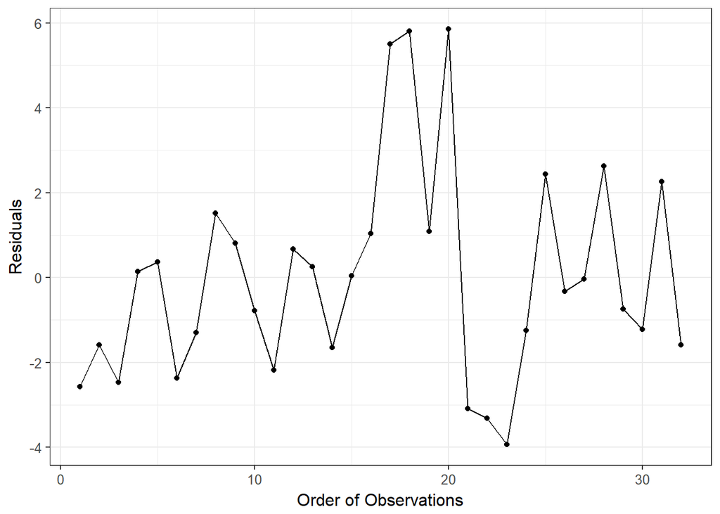

```r
qplot(data = mtcars.augment,
      y = .resid,
      x = seq_along(.resid),
      geom = c("line", "point")) +
  labs(y = "Residuals",
       x = "Order of Observations")
```

The nice thing about this graphic is that the only thing that changes is the dataset from which to pull the residuals.

## Diagnostic Plots: Residual vs. Fitted Values

A plot of the residuals against the fitted values can be helpful for assessing various conditions.

1. Use the augmented dataset (see above) that contains the residuals.
2. Set `y = .resid`.
3. Set `x = .fitted`.
4. Set `geom = "point"`.

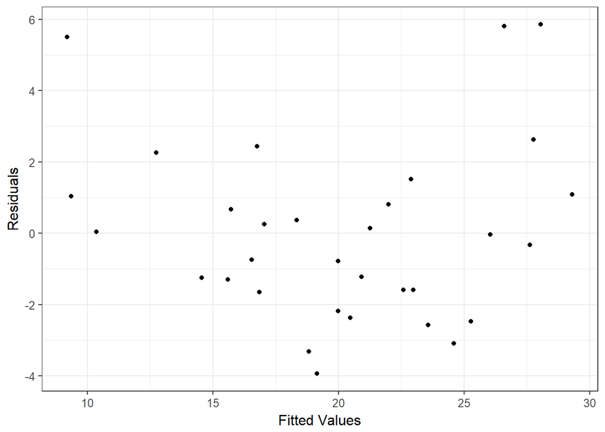

```r
qplot(data = mtcars.augment,
      y = .resid,
      x = .fitted,
      geom = "point") +
  labs(y = "Residuals",
       x = "Fitted Values")
```

It can often be helpful to include a smoother on this graphic. This can be done easily by adjusting the `geom` option.

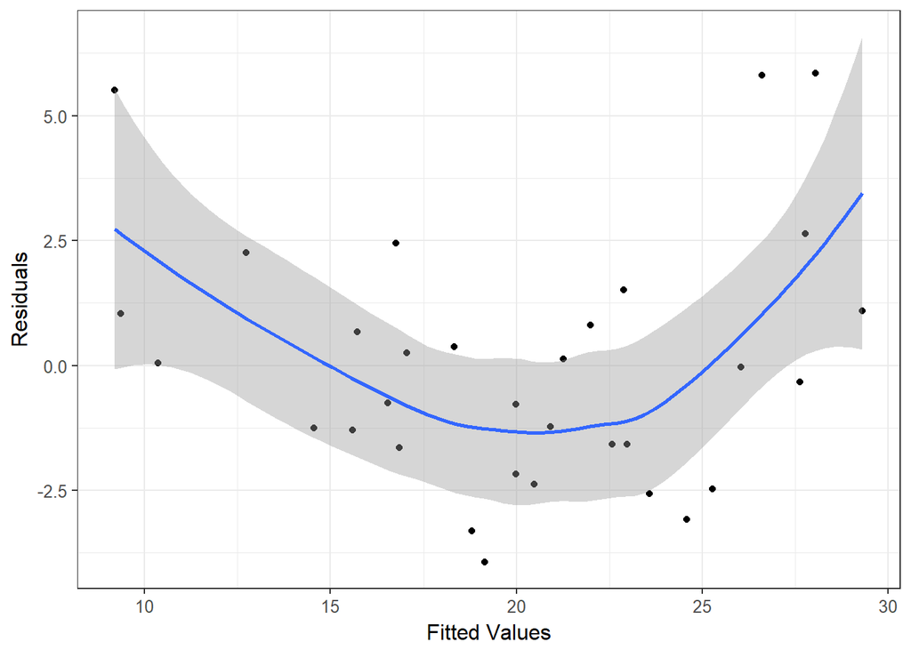

```r
qplot(data = mtcars.augment,
      y = .resid,
      x = .fitted,
      geom = c("point", "smooth")) +
  labs(y = "Residuals",
       x = "Fitted Values")
```

## Diagnostic Plots: Probability Plot

A probability plot, or quanitile-quantile plot (QQ-plot for short) can also be made of the residuals.

1. Use the augmented dataset (see above) that contains the residuals.
2. Set `sample = .resid`.
3. Set `geom = "qq"`.

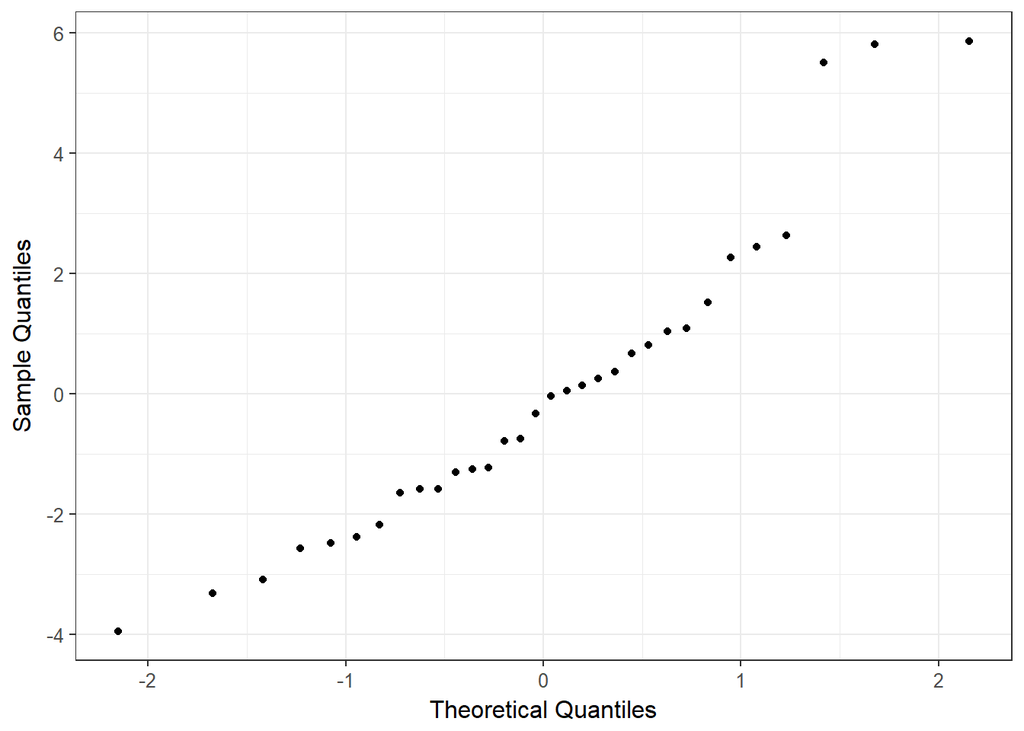

```r
qplot(data = mtcars.augment,
      sample = .resid,
      geom = "qq") +
  labs(x = "Theoretical Quantiles",
       y = "Sample Quantiles")
```

# Frequently Asked Questions

There are some things students run into a lot. Here are some common situations.

## I just want to look at my dataset; how?

The easiest way is to go to the “Environment” tab in RStudio and double-click on the name of the dataset. It will open a spread-sheet like interface for looking at your dataset.

## My variable name has spaces and R does not like it!

Variable names which have spaces in them need to be wrapped in back ticks. Technically, all variable names can be done this way, but it is a requirement when the variable name has spaces. For example, the following is allowed:

```r
mtcars = mtcars %>%
  mutate(`Miles Per Gallon` = mpg)
```

## Why does my code block not have a green arrow?

A code block should be completely separate from surrounding text. So, be sure there is a blank line both before the code block and after it. Usually, this fixes the problem.

## How can I make a caption for my graphic?

In your code chunk, include the `fig.cap` option. For example, a code chunk might look like the following:

````
```{r, fig.cap="Relationship between fuel efficiency and the horsepower of a vehicle."}
qplot(data = mtcars
      x = hp
      y = mpg) +
  labs(x = "Horse Power",
       y = "Miles per Gallon")
```
````

This block would produce the following image (notice caption below image):

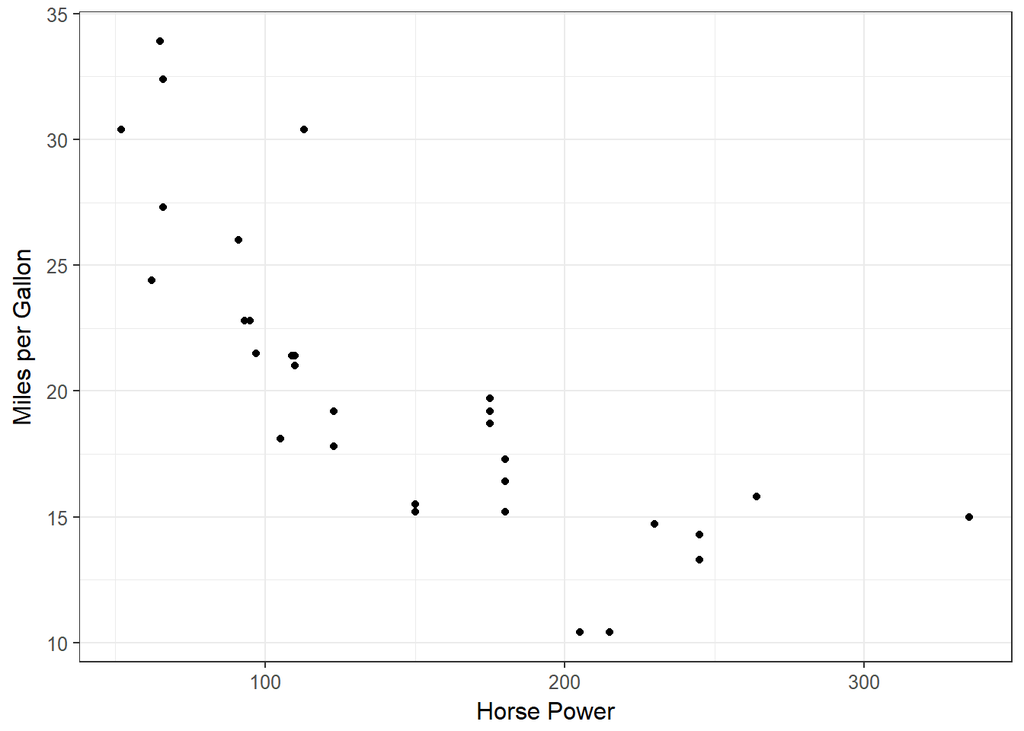

Relationship between fuel efficiency and the horsepower of a vehicle.

## R is not treating my “grouping” variable correctly!

Generally, this happens when your “grouping” variable is a number instead of a phrase. For example, in the `mtcars` dataset, the variable `cyl` takes values 4, 6, or 8. However, R does not know that these values represent groups instead of actual values. In order to get the program to recognize it as a group, rewrite the variable using `factor()`:

```r
mtcars = mtcars %>%
  mutate(cyl = factor(cyl))
```

Now, `cyl` will be treated as a grouping variable. This needs to be done only once and will work for all subsequent graphics and models constructed.

Note: you could also recode the variable manually if you wanted to:

```r
mtcars = mtcars %>%
  mutate(cyl = recode(cyl,
                      `4` = "4 Cylinder",
                      `6` = "6 Cylinder",
                      `8` = "8 Cylinder"))
```

The choice is yours.